# STA 506 - Midterm Examination

Matthew Gray

Due: Sunday, 03/08 at 11:59 PM

# **Midterm Exam Objectives**

- Understand the definition and relationship between PDFs and CDFs, including their non-parametric estimators: the empirical distribution function and kernel density estimation (KDE).
- Estimate sampling distributions using simulation-based methods, specifically the bootstrap.
- Derive point estimates of parameters using the method of moments and maximum likelihood estimation (MLE).
- Describe the asymptotic (normal) and bootstrap sampling distributions of maximum likelihood estimators.
- Apply all the above inferential procedures in a programming environment to perform numerical data analysis.

# **Policies of Using AI Tools**

- **Policy on AI Tool Use**: Students must adhere to the AI tool policy specified in the course syllabus. The direct copying of AI-generated content is strictly prohibited. All submitted work must reflect your own understanding; where external tools are consulted, content must be thoroughly rephrased and synthesized in your own words.
- **Code Inclusion Requirement**: Any code included in your essay must be properly commented to explain the purpose and/or expected output of key code lines. Submitting AI-generated code without meaningful, student-added comments will not be accepted.

# **Policies of the Midterm Exam**

- This exam must be completed independently. Collaboration with others is not permitted.
- You may consult class notes and online resources. However, please ensure that your use of AI tools complies with the AI policy established for this course.
- All work must be submitted by the deadline. Submissions (including partial work) received after the deadline will not be accepted.

# **Submission Preparation**

Since this exam involves derivations, you can use the following approaches to prepare your submission and save time:

1. Handwrite the derivation on paper and take a photo. From there, you can either use AI tools to convert it into LaTeX code and paste it into RMarkdown, or insert the image directly into your RMarkdown document, following the example shown in class this week.
2. Prepare the formulas using other non-programmatic editors and take a screenshot to embed the image in your RMarkdown document using `knitr::include_graphics`.
3. Compile all handwritten derivations into a single file and submit it as an attachment.

Please follow the same submission procedure as used for the weekly assignments.

# **Exam Questions**

**Caution**: *Please follow the suggested expressions and guided steps to complete the exam. Other approaches, such as transformations that trivialize the problems, will not meet the exam objectives.*

## **Log-normal Distribution**

The log-normal distributions have been widely used in many different fields such as finance and economics, engineering and reliability, environmental science, medical and biology etc.

If $X$ follows a lognormal distribution:

$$f(x; \mu, \sigma^2) = \frac{1}{x\sqrt{2\pi \sigma^2}}
\exp\left[-\frac{(\ln x - \mu)^2}{2\sigma^2}\right], \quad x > 0$$

where $\mu \in \mathbb{R}$ is the mean of $\ln X$ and $\sigma^2 > 0$ is the variance of $\ln X$.

**Caution:** *$\mu$ and $\sigma^2$ are not population mean and variance of the lognormal distribution!*. **Instead, we will use $\mu_{LN}$ and $\sigma_{LN}^2$ to denote the lognormal mean and variance respectively.**

For an i.i.d. random sample $x_1, x_2, \dots, x_n$:

$$\begin{align*}
\ell(\mu, \sigma^2) &= \sum_{i=1}^n \ln f(x_i; \mu, \sigma^2) \\
&= -\frac{n}{2} \ln(2\pi) - \frac{n}{2} \ln \sigma^2 - \sum_{i=1}^n
\ln x_i
- \frac{1}{2\sigma^2} \sum_{i=1}^n (\ln x_i - \mu)^2
\end{align*}$$

The $k$-th moment of log normal distribution given by

$$\boxed{ \mathbb{E}[X^k] = \exp\left( k\mu + \frac{1}{2} k^2 \sigma^2
\right). }$$

Particularly, the mean of the above lognormal distribution, denoted by $\mu_{LN}$, is given by

$$\mu_{LN} = \mathbb{E}[X] = \exp\left( \mu + \frac{1}{2} \sigma^2
\right).$$

Once the parameters were estimated, say $(\overline{\mu}, \overline{\sigma^2})$, we can use **the plug-in Principle** to estimate the lognormal mean by

$$\boxed{\overline{\mu_{LN}} = \exp\left( \overline{\mu} +
\frac{1}{2} \overline{\sigma^2} \right).}$$

**Working Dataset**: A reservoir engineer at an oil exploration company has recently drilled 50 new wells in a shale formation. According to geological theory, the size of oil reserves in this type of formation is often modeled using a log-normal distribution. The engineer is responsible for estimating the typical reserve size and quantifying the uncertainty of these estimates for a presentation to senior management. The estimated ultimate recovery (EUR) for the 50 wells, measured in thousands of barrels (Mbbl), is as follows:

```
17.3, 24.8, 8.2, 31.5, 14.1, 42.7, 11.9, 55.3, 21.4, 9.7, 36.2, 18.6, 63.1, 13.2, 28.9,
47.5, 19.8, 7.5, 33.4, 52.1, 16.0, 25.9, 38.7, 10.3, 44.2, 22.5, 58.6, 12.8, 30.3, 48.9,
20.1, 35.4, 15.7, 60.2, 26.7, 41.3, 18.1, 53.8, 23.9, 46.2, 29.4, 37.6, 14.9, 50.5, 32.8,
19.3, 56.7, 11.2, 39.5, 27.1
```

This assignment focuses on finding the asymptotic sampling distributions of the MLE $\hat{\mu}$ and $\hat{\sigma^2}$ corresponding to $\mu$ and $\sigma^2$ based on an environmental study data.

## **Question 1**: Method of Moments Estimation (MME) of $\mu$ and $\sigma^2$

Estimate the parameters $\mu$ and $\sigma^2$ (*caution: not $\sigma$!*) from the raw oil reserve data using the given $k$-th moment function. Organize your work into three parts:

1. Derive the system of two equations for the method of moments estimators (MMEs) of $\mu$ and $\sigma^2$.

$$\boxed{
\begin{aligned}
E[X] = m_1 &\longrightarrow e^{(\hat{\mu} + \frac{1}{2}
\widehat{\sigma^2})} = m_1 \\
E[X^2] = m_2 &\longrightarrow e^{(2\hat{\mu} + \frac{1}{2} 2^2
\widehat{\sigma^2})} = m_2
\end{aligned}
}$$

2. Derive the closed-form expressions for the MMEs of $\mu$, $\sigma^2$, and $\mu_{LN}$, denoted by $\widetilde{\mu}$, $\widetilde{\sigma^2}$, and $\widetilde{\mu_{LN}}$, respectively.

Isolate $\hat{\mu}$ from the first moment equation:
$$\begin{aligned}
\ln e^{(\hat{\mu} + \tfrac{1}{2}\hat{\sigma^2})} &= \ln m_1 \\
\hat{\mu} + \tfrac{1}{2}\hat{\sigma^2} &= \ln m_1 \\
\hat{\mu} &= \ln m_1 - \tfrac{1}{2}\hat{\sigma^2}
\end{aligned}$$

Substitute $\hat{\mu}$ into the second moment equation and isolate $\hat{\sigma^2}$:

$$\begin{aligned}
e^{(2(\ln m_1 - \frac{1}{2} \hat{\sigma^2}) + \frac{1}{2} 2^2
\hat{\sigma^2})} &= m_2 \\
e^{(2 \ln m_1 - \hat{\sigma^2} + 2\hat{\sigma^2})} &= m_2 \\
e^{(2 \ln m_1 + \hat{\sigma^2})} &= m_2 \\
2 \ln m_1 + \hat{\sigma^2} &= \ln m_2 \\
\hat{\sigma^2} &= \ln m_2 - 2 \ln m_1
\end{aligned}$$

$$\boxed{
\hat{\sigma^2} = \ln(m_2) - 2 \ln(m_1)
}$$

Plug in $\hat{\sigma^2}$ to find $\hat{\mu}$ in terms of $m_1$ and $m_2$:
$$\begin{align*}
\hat{\mu} &= \ln m_1 - \tfrac{1}{2} \hat{\sigma^2} \\
&= \ln m_1 - \tfrac{1}{2} (\ln m_2 - 2 \ln m_1) \\
\hat{\mu} &= 2 \ln m_1 - \tfrac{1}{2} \ln m_2
\end{align*}$$

$$\boxed{
\hat{\mu} = 2 \ln(m_1) - \frac{1}{2} \ln(m_2)
}$$

Plug in $\hat{\sigma^2}$ and $\hat{\mu}$ to find $\hat{\mu}_{LN}$:
$$\begin{align*}
\widehat{\mu}_{LN} &= e^{(\hat{\mu} + \frac{1}{2} \hat{\sigma^2})}
\\
&= e^{\left( \left[2\ln(m_1) - \tfrac{1}{2}\ln(m_2)\right] +
\tfrac{1}{2}\left[\ln(m_2) - 2\ln(m_1)\right] \right)} \\
&= e^{\ln(m_1)}
\end{align*}$$

$$\boxed{\widehat{\mu}_{LN} = m_1}$$

3. Write an R function that outputs the MMEs $\widetilde{\mu}$, $\widetilde{\sigma^2}$, and $\widetilde{\mu_{LN}}$ based on the given data set.

```r
# --------------------------- STORING SAMPLE DATA -----------------------------------------------
eur_sample <- c(17.3, 24.8, 8.2, 31.5, 14.1, 42.7, 11.9, 55.3, 21.4, 9.7, 36.2, 18.6, 63.1, 13.2, 28.9,
47.5, 19.8, 7.5, 33.4, 52.1, 16.0, 25.9, 38.7, 10.3, 44.2, 22.5, 58.6, 12.8, 30.3, 48.9,
20.1, 35.4, 15.7, 60.2, 26.7, 41.3, 18.1, 53.8, 23.9, 46.2, 29.4, 37.6, 14.9, 50.5, 32.8,
19.3, 56.7, 11.2, 39.5, 27.1)

# --------------------------- CREATING MME FUNCTION ------------------------------------------------------
get_mme <- function(data)
# get_mme: function with one arguments
# data: sample date. In this case, estimated ultimate recovery (measured in 1000s of barrels of oil)
{
# this bracket begins the definition of the function
m1 <- mean(eur_sample)
# m1: first moment of the sample
m2 <- mean(eur_sample^2)
# m2: second moment of the sample
sig_sqr_hat <-  log(m2) - 2*log(m1)
# sig_sqr_hat: sigma squared estimate from part 1b
mu_hat <-  2*log(m1) - .5*log(m2)
# mu_hat: mu estimate from part 1b
mu_ln_hat <-  m1
# mu_ln_hat: first moment estimate from part 1b
return(list(sigma_sq_hat = sig_sqr_hat, mu_hat = mu_hat, mu_ln_hat = mu_ln_hat))
}
# this bracket ends the definition of the function
get_mme(eur_sample)
```

```
$sigma_sq_hat
[1] 0.2339652

$mu_hat
[1] 3.301269

$mu_ln_hat
[1] 30.516
```

## **Question 2**: Finding the MLE of $\mu$ and $\sigma^2$

This question involves two parts:

(1). Derive the score functions (i.e., the gradient of the log-likelihood) for the parameters of the log-normal distribution, and set them to zero to obtain the system of score equations. Begin with the full log-likelihood and compute its partial derivatives with respect to $\mu$ and $\sigma^2$. [Hint: letting $\beta = \sigma^2$ may simplify differentiation.]

Assume that $\{x_1, x_2, \cdots, x_n \} \to \text{ LN }(\mu, \sigma^2)$ with density function given by

$$\ell(\mu, \sigma^2) = -\frac{n}{2} \ln(2\pi) - n \ln \sigma -
\sum_{i=1}^n \ln x_i
- \frac{1}{2\sigma^2} \sum_{i=1}^n (\ln x_i - \mu)^2$$
Rewrite the second term to be $\sigma^2$:
$$\ell(\mu, \sigma^2)
= -\frac{n}{2}\ln(2\pi)
- \frac{n}{2}\ln(\sigma^2)
- \sum_{i=1}^{n}\ln(x_i)
- \frac{1}{2\sigma^2}\sum_{i=1}^{n}(\ln x_i - \mu)^2$$

Take partial derivative with respect to $\sigma^2$:
$$\boxed{
\frac{\partial \ell}{\partial \sigma^2}
=
-\frac{n}{2\sigma^2}
+
\frac{1}{2(\sigma^2)^2}
\sum_{i=1}^{n}(\ln x_i - \mu)^2
}$$

Take partial derivative with respect to $\mu$:
$$\frac{\partial}{\partial \mu}
\left[
-\frac{1}{2\sigma^2}
\sum_{i=1}^{n}(\ln x_i - \mu)^2
\right]
=
-\frac{1}{2\sigma^2}
\sum_{i=1}^{n}
\left[
2(\ln x_i - \mu)(-1)
\right]$$

$$\boxed{
\frac{\partial \ell}{\partial \mu}
= \frac{1}{\sigma^2} \sum_{i=1}^{n} (\ln x_i - \mu)
}$$

(2). Perform some algebra to find the closed form of the MLE of $\mu$ and $\sigma^2$, denoted by $\widehat{\mu}$ and $\widehat{\sigma^2}$.

Finding $\hat{\mu}$:
$$\text{Score equation:}\quad
\frac{\partial \ell}{\partial \mu} = 0
\quad\Longrightarrow\quad
\frac{1}{\sigma^2} \sum_{i=1}^{n} (\ln x_i - \mu) = 0.$$

$$\Longrightarrow\quad
n\mu = \sum_{i=1}^{n} \ln x_i.$$

$$\boxed{
\hat{\mu} = \frac{1}{n} \sum_{i=1}^{n} \ln x_i
}$$

Finding $\hat{\sigma^2}$:
$$\text{Score equation:}\quad
\frac{\partial \ell}{\partial \sigma^2} = 0
\quad\Longrightarrow\quad
-\frac{n}{2\sigma^2}
+
\frac{1}{2(\sigma^2)^2}
\sum_{i=1}^{n}(\ln x_i - \mu)^2
= 0.$$

$$\Longrightarrow\quad
\frac{1}{2(\sigma^2)^2}
\sum_{i=1}^{n}(\ln x_i - \mu)^2
=
\frac{n}{2\sigma^2}.$$

$$\Longrightarrow\quad
n\sigma^2
=
\sum_{i=1}^{n}(\ln x_i - \mu)^2.$$

$$\boxed{
\hat{\sigma^2}
= \frac{1}{n} \sum_{i=1}^{n} \bigl(\ln x_i - \hat{\mu}\bigr)^2
}$$

(3). Recall that lognormal population mean (i.e., the first moment) is

$$\mu_{LN} = \mathbb{E}[X] = \exp\left( \mu + \frac{1}{2} \sigma^2
\right).$$

Using the relationship between variance and the first and second moments, $\text{Var}(X) = \mathbb{E}[X^2] - \left(\mathbb{E}[X]\right)^2$, we derive the population variance of the lognormal distribution, denoted as $\sigma_{\text{LN}}^2$. This result will be used in applying the Central Limit Theorem in subsequent questions.
$$\begin{aligned}
\sigma^2_{LN} &= E[X^2] - E^2[X] \\
&= e^{(2\mu + \frac{1}{2} 2^2 \sigma^2)} - e^{(\mu + \frac{1}{2}
\sigma^2)} e^{(\mu + \frac{1}{2} \sigma^2)} \\
&= e^{(2\mu + 2\sigma^2)} - e^{(2\mu + \sigma^2)}
\end{aligned}$$

$$\boxed{
\sigma_{LN}^2
= \exp(2\mu + \sigma^2)\bigl(e^{\sigma^2} - 1\bigr).
}$$

## **Question 3**: Sampling Distribution of Lognormal **Sample Mean** $\widehat{\mu_{LN}}$

We have derived two different estimators of lognormal population mean $\mu_{LN}$. This Question focuses on the sampling distribution of lognormal sample sample means based on MLE. The following are detailed instructions.

(1). Write an R function to estimate the MLE of $\mu$ and $\sigma^2$, denoted by $\widehat{\mu}$ and $\widehat{\sigma^2}$ and return the MLE of $\mu_{LN}$, denoted by $\widehat{\mu_{LN}}$.

```r
# --------------------------- STORING SAMPLE DATA ---------------------------------------------------------
eur_sample <- c(17.3, 24.8, 8.2, 31.5, 14.1, 42.7, 11.9, 55.3, 21.4, 9.7, 36.2, 18.6, 63.1, 13.2, 28.9,
47.5, 19.8, 7.5, 33.4, 52.1, 16.0, 25.9, 38.7, 10.3, 44.2, 22.5, 58.6, 12.8, 30.3, 48.9,
20.1, 35.4, 15.7, 60.2, 26.7, 41.3, 18.1, 53.8, 23.9, 46.2, 29.4, 37.6, 14.9, 50.5, 32.8,
19.3, 56.7, 11.2, 39.5, 27.1)

# --------------------------- CREATING LOG NORNAL MU MLE FUNCTION -----------------------------------------
get_mle_mu_ln <- function(data)
# get_mle_mu_ln: function with one argument
# data: sample date. In this case, estimated ultimate recovery (measured in 1000s of barrels of oil)
{
# this bracket begins the definition of the function
n <- length(data)
# n: sample size
mle_mu_hat <- (1/n)*sum(log(data))
mle_sig_sqr_hat <- (1/n)*sum((log(data)-mle_mu_hat)^2)
mle_mu_ln_hat <- exp(mle_mu_hat + .5*mle_sig_sqr_hat)
return(mle_mu_ln_hat)
}
# this bracket ends the definition of the function
get_mle_mu_ln(eur_sample)
```

```
[1] 30.94264
```

(2). Take 1000 Bootstrap samples from the raw oil data set. For each bootstrap sample, call the above R function to find the **bootstrap MLE** of $\mu_{LN}$, denoted by $\widehat{\mu_{LN}^*}^{(1)}, \widehat{\mu_{LN}^*}^{(2)}, \cdots, \widehat{\mu_{LN}^*}^{(1000)}$.

```r
# -----------------DEFINING THE BOOTSTRAP FUNCTION -----------------------------------------------------------------------
bootstrap_mle_mu_ln <- function(data, B)
# bootstrap_mle_mu_ln: function with two arguments
# data: the random sample from the population with which you will make bootstrap samples
# B: the number of bootstrap samples you plan to create
{
# this bracket begins the definition of the function
n <- length(data)
# n: the number of observations in your random sample
t_obs <- get_mle_mu_ln(data)
# t_obs: the computed statistic for your original random sample. This only needs to be computed once.
# this will not become part of your bootstrap distribution. This is your actual estimate from the real world.
boot_dist <- numeric(B)
# boot_dist: empty vector of length B that will eventually store all the bootstrap statistics you will compute

for (b in 1:B)
{
# everything inside of this bracket will loop B times, filling the vectors boot_first_mom_dist and boot_second_mom_dist
indices <- sample(1:n, n, replace = TRUE)
# the sample function samples with replacement from the vector 1:n (the integers 1,2,3, ... n) until sample size is n
# the result is a vector called indices which stores the position of data values we'd like in our bootstrap sample
bootstrap_sample <- data[indices]
# we index our data with the indices vector to create our bootstrap sample
boot_dist[b] <- get_mle_mu_ln(bootstrap_sample)
# we compute the mle log normal mean of our bootstrap sample
# and then feed the value into our bootstrap distribution vector, filling in position b
}
# everything after this bracket is outside the loop

return(list(observed_mle_mu_ln = t_obs, distribution_mle_mu_ln = boot_dist))
# save all of our data in a list
}
# this bracket ends the definition of the function
```

```r
# -----------------CALL THE BOOTSTRAP FUNCTION -------------------------------------
boot_list <- bootstrap_mle_mu_ln(eur_sample,1000)
```

(3). Using kernel density estimation approach to estimate the bootstrap density curves based on the bootstrap MLEs: $\widehat{\mu_{LN}^*}^{(1)}, \widehat{\mu_{LN}^*}^{(2)}, \cdots, \widehat{\mu_{LN}^*}^{(1000)}$.

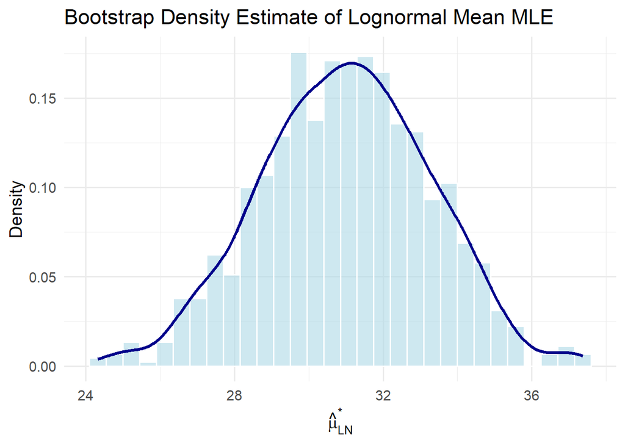

```r
boot_mle_vals <- boot_list$distribution_mle_mu_ln

ggplot(data.frame(mle = boot_mle_vals), aes(x = mle)) +
  geom_histogram(aes(y = ..density..),
                 bins = 30,
                 fill = "lightblue",
                 color = "white",
                 alpha = 0.6) +
  geom_density(color = "darkblue", size = 1.2) +
  labs(
    title = "Bootstrap Density Estimate of Lognormal Mean MLE",
    x = expression(hat(mu)[LN]^"*"),
    y = "Density"
  ) +
  theme_minimal(base_size = 14)
```

(4). In order to find the asymptotic sampling distribution using the **central limit theorem (CLT)**. That is, when sample size is large,

$$\bar{X} \to N \left(\mu_{LN}, \frac{\sigma_{LN}}{\sqrt{n}}\right)$$

where $\mu_{LN}$ and $\sigma_{LN}$ can be estimated by using the **plug-in principle of MLE**. Based on the asymptotic sampling distribution of **lognormal sample mean** $\bar{X}$, add the asymptotic density curve to the above Bootstrap kernel density curve.

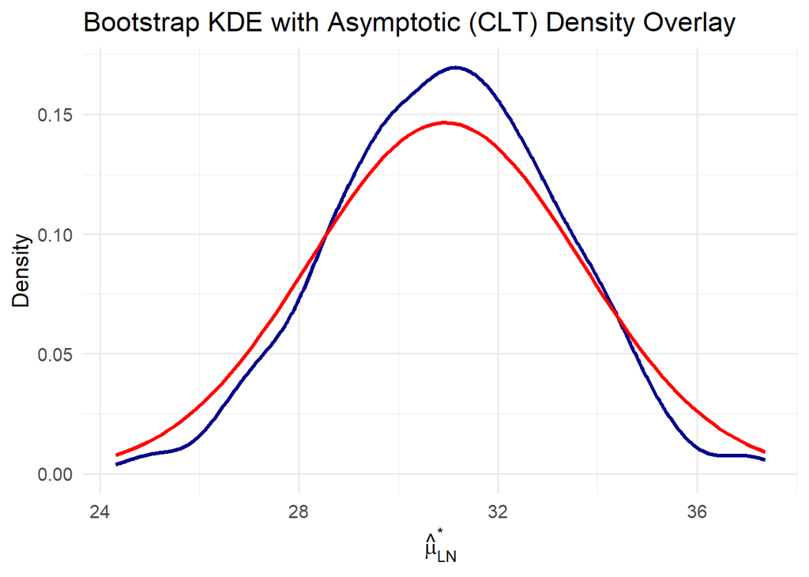

```r
boot_vals <- boot_list$distribution_mle_mu_ln

# Plug-in estimates from your original sample
mle_mu_hat <- mean(log(eur_sample))
# mle_mu_hat: mle mu hat from part 2.2
mle_sig_sqr_hat <- mean((log(eur_sample)-mle_mu_hat)^2)
# mle_sig_sqr_hat: mle sigma square hat from part 2.2

mle_mu_ln_hat <- exp(mle_mu_hat + .5*mle_sig_sqr_hat)
# mle_mu_ln_hat: log normal mu from part 2.3
mle_sig2_LN_hat <- exp(2*mle_mu_hat + mle_sig_sqr_hat) * (exp(mle_sig_sqr_hat) - 1)
# mle_sig2_LN_hat: log normal sigma square from part 2.3

n <- length(eur_sample)
# n: the number of observations in your random sample

asymp_sd <- sqrt(mle_sig2_LN_hat / n)
# Asymptotic SD of sample mean

ggplot(data.frame(mle = boot_vals), aes(x = mle)) +
  geom_density(color = "darkblue", size = 1.2) +
  stat_function(
    fun = dnorm,
    args = list(mean = mle_mu_ln_hat, sd = asymp_sd),
# plug in the mean and standard deviation for Normal overlay
    color = "red",
    size = 1.2
  ) +
  labs(
    title = "Bootstrap KDE with Asymptotic (CLT) Density Overlay",
    x = expression(hat(mu)[LN]^"*"),
    y = "Density"
  ) +
  theme_minimal(base_size = 14)
```

(5). Write a short summary to compare the two sampling distributions of the sample mean of the lognormal distribution.

## **Question 4**: Extra Bonus Credit

Derive the Hessian matrix by computing the second-order partial derivatives of the log-likelihood function (with respect to $\mu$ and $\sigma^2$). Then, translate the derived Hessian into an R function that takes the MLEs of the parameters and the data as inputs and returns the Hessian matrix. Finally, compare your analytically derived Hessian with the numerical Hessian returned by `optim()`.
$$\frac{\partial \ell}{\partial \sigma^2}
= -\frac{n}{2\sigma^2}
+ \frac{1}{2(\sigma^2)^2}
\sum_{i=1}^{n} (\ln x_i - \mu)^2$$

$$\boxed{
\frac{\partial^2 \ell}{\partial (\sigma^2)^2}
=
\frac{n}{2(\sigma^2)^2}
-
\frac{1}{(\sigma^2)^3}
\sum_{i=1}^n (\ln x_i - \mu)^2
}$$

$$\boxed{
\frac{\partial}{\partial \mu}
\left(
\frac{\partial \ell}{\partial \sigma^2}
\right)
=
-\frac{1}{(\sigma^2)^2}
\sum_{i=1}^n (\ln x_i - \mu)
}$$

$$\begin{align*}
\frac{\partial \ell}{\partial \mu}
&= \frac{1}{\sigma^2} \sum_{i=1}^{n} (\ln x_i - \mu)
= \frac{1}{\sigma^2} \left( \sum_{i=1}^n \ln x_i - n\mu \right)
\end{align*}$$

$$\boxed{
\frac{\partial^2 \ell}{\partial \mu^2}
= -\frac{n}{\sigma^2}
}$$

$$\boxed{
\frac{\partial}{\partial \sigma^2}
\left(
\frac{\partial \ell}{\partial \mu}
\right)
=
-\frac{1}{(\sigma^2)^2}
\sum_{i=1}^n (\ln x_i - \mu)
}$$

**ANALYTICALLY DERIVED**

```r
# -----------------DEFINING THE HESSIAN FUNCTION -----------------------------------------------------------------------
get_hessian <- function(data)
# get_hessian: function with one argument
# data: the random sample from the population
{
# this bracket begins the definition of the function
n <- length(data)
# n: the number of observations in your random sample
mle_mu <- (1/n)*sum(log(data))
# mle_mu: maximum likelihood estimator of mu derived in part 2.2
mle_sig_sqr <- (1/n)*sum((log(data)-mle_mu)^2)
# mle_sig_sqr: maximum likelihood estimator of sigma square derived in part 2.2
# below are four algorithms for the second order partial derivatives of the log likelihood function
d_sig2_sig2 <- (n/(2*mle_sig_sqr^2)) - (1/mle_sig_sqr^3)*sum((log(data)-mle_mu)^2)
# d_sig2_sig2: partial derivative with respect to sigma square. then partial derivative with respect to sigma square.
d_sig2_mu <- (-1/mle_sig_sqr^2)*sum(log(data)-mle_mu)
# d_sig2_mu: partial derivative with respect to sigma square. then partial derivative with respect to mu.
d_mu_mu <- -n/mle_sig_sqr
# d_mu_mu: partial derivative with respect to mu. then partial derivative with respect to mu.
d_mu_sig2 <- (-1/mle_sig_sqr^2)*sum(log(data)-mle_mu)
# d_mu_sig2: partial derivative with respect to mu. then partial derivative with respect to sigma square.
H <- matrix(c(d_mu_mu, d_mu_sig2, d_sig2_mu, d_sig2_sig2), nrow = 2, byrow = TRUE)
return(H)
# save all of our data to the matrix H
}
# this bracket ends the definition of the function
# --------------------------- STORING SAMPLE DATA ---------------------------------------------------------
eur_sample <- c(17.3, 24.8, 8.2, 31.5, 14.1, 42.7, 11.9, 55.3, 21.4, 9.7, 36.2, 18.6, 63.1, 13.2, 28.9,
47.5, 19.8, 7.5, 33.4, 52.1, 16.0, 25.9, 38.7, 10.3, 44.2, 22.5, 58.6, 12.8, 30.3, 48.9,
20.1, 35.4, 15.7, 60.2, 26.7, 41.3, 18.1, 53.8, 23.9, 46.2, 29.4, 37.6, 14.9, 50.5, 32.8,
19.3, 56.7, 11.2, 39.5, 27.1)
# -----------------CALLING THE HESSIAN FUNCTION ------------------------------------------------------------
Hess <- get_hessian(eur_sample)
Hess
```

```
              [,1]          [,2]
[1,] -1.528123e+02  1.037019e-13
[2,]  1.037019e-13 -2.335158e+02
```

**OPTIM OUTPUT**

```r
# --------------------------- STORING SAMPLE DATA ---------------------------------------------------------
eur_sample <- c(17.3, 24.8, 8.2, 31.5, 14.1, 42.7, 11.9, 55.3, 21.4, 9.7, 36.2, 18.6, 63.1, 13.2, 28.9,
47.5, 19.8, 7.5, 33.4, 52.1, 16.0, 25.9, 38.7, 10.3, 44.2, 22.5, 58.6, 12.8, 30.3, 48.9,
20.1, 35.4, 15.7, 60.2, 26.7, 41.3, 18.1, 53.8, 23.9, 46.2, 29.4, 37.6, 14.9, 50.5, 32.8,
19.3, 56.7, 11.2, 39.5, 27.1)
# --------------------------- CREATING INITIAL VALUES FUNCTION -----------------------------
get_mle_mu_sig2 <- function(data)
# get_mle_mu_sig2: function with one argument
# data: sample date. In this case, estimated ultimate recovery (measured in 1000s of barrels of oil)
{
# this bracket begins the definition of the function
n <- length(data)
# n: sample size
mle_mu_hat <- (1/n)*sum(log(data))
# mle_mu_hat: mle mu estimate from part 2.2
mle_sig_sqr_hat <- (1/n)*sum((log(data)-mle_mu_hat)^2)
# mle_sig_sqr_hat: mle sigma square estimate from part 2.2
return(c(mle_mu_hat,mle_sig_sqr_hat))
}
# this bracket ends the definition of the function

# --------------------------- GET INITIAL VALUES FOR PARAMETERS --------------------------------------
initial_params <- get_mle_mu_sig2(eur_sample)
# These are the values you expect the parameters to take
```

```r
# --------------------------- CREATING LOGNORMAL LOG-LIKELIHOOD FUNCTION ------------------------------------------
lognormal_loglik <- function(params, data)
# lognormal_loglik: function with two arguments
# params: a vector containing parameters mu and sigma square
# data: sample date. In this case, estimated ultimate recovery of oil
{
# this bracket begins the definition of the function
mu <- params[1]
# mu: stored in the first position of params vector
sigma_sqr <- params[2]
# sigma_sqr: sigma square. stored in the second position of params vector
n <- length(data)
# n: sample size
loglik <- (-n/2)*log(2*pi) - (n/2)*log(sigma_sqr) - sum(log(data)) - (1/(2*sigma_sqr))*sum((log(data)-mu)^2)
# loglik: Log-likelihood for lognormal distribution
return(loglik)
}
# this bracket ends the definition of the function


# --------------------------- CREATING LOGNORMAL SCORE (GRADIENT) FUNCTIONS --------------------------------------
lognormal_score <- function(params, data)
# lognormal_score: function with two arguments
{
mu <- params[1]
# mu: stored in the first position of params vector
sigma_sqr <- params[2]
# sigma_sqr: sigma square. stored in the second position of params vector
n <- length(data)
# n: sample size
grad_sig_sqr <- (-n/(2*sigma_sqr)) + (1/(2*(sigma_sqr^2)))*sum((log(data)-mu)^2)
# grad_sig_sqr: gradient for the sigma square parameter
# partial derivative of the log-likelihood function with respect to sigma square
grad_mu <- (1/sigma_sqr)*sum(log(data)-mu)
# grad_mu: gradient for the mu parameter
# partial derivative of the log-likelihood function with respect to sigma square
return(c(grad_mu, grad_sig_sqr))
}
# this bracket ends the definition of the function
```

```r
# --------------------------- COMPUTE HESSIAN WITH OPTIM() -----------------------------------------------
optim_result <- optim(
par = initial_params,
fn = lognormal_loglik,
gr = lognormal_score,
data = eur_sample,
method = "L-BFGS-B",
# Nelder-Mead method
hessian = TRUE,
# Compute the second order partial derivatives and build the Hessian matrix
control = list(trace = FALSE,
fnscale = -1,
# this flips the direction of optimization so that optim() maximizes log-likelihood instead of minimizing
maxit = 500,
# sets the max number of iterations optim() is allowed to take before it stops
# this is a safeguard so optim() does not run forever
abstol = 1e-8)
# sets an absolute convergence tolerance so optim() stops when it is very close to a solution
)
optim_result$hessian # print results
```

```
              [,1]          [,2]
[1,] -1.528123e+02  5.185142e-14
[2,]  5.185142e-14 -2.335224e+02
```

**Comparison:** These methods produce nearly identical results. Compute one and then check your work with the other.